# Homework 4

Agnieszka Sitko

# Part I - adding main effects

In this scenario there are two dummy variables `levels1` and `levels2`. If an observation takes the value 1 in `levels1`, we add 0.7 to the observation. Therefore, we should observe statistically significant main effect of the variable `levels1`.

## Simulation

```r
set.seed(21)
N <- 5000
M <- 500
pvals <- replicate(N, {
      epsilon <- rnorm(M)
      levels1 <- sample(c(rep(0, 0.9 * M), rep(1, 0.1 * M)))
      levels2 <- sample(c(rep(0, 0.9 * M), rep(1, 0.1 * M)))
      y <- levels1 * 0.7 + epsilon

      anova(lm(y~levels1*levels2))[[5]][c(1,2,3)]

})
```

## Calculating probablities

Probabilities of rejecting given null hypothesis are presented below:

1. probablity of rejecting H0: the means in groups designated by the division of the variable levels1 are equal (power of the test)

As this null hypothesis is not true, we are expecting to get the value close to 1.

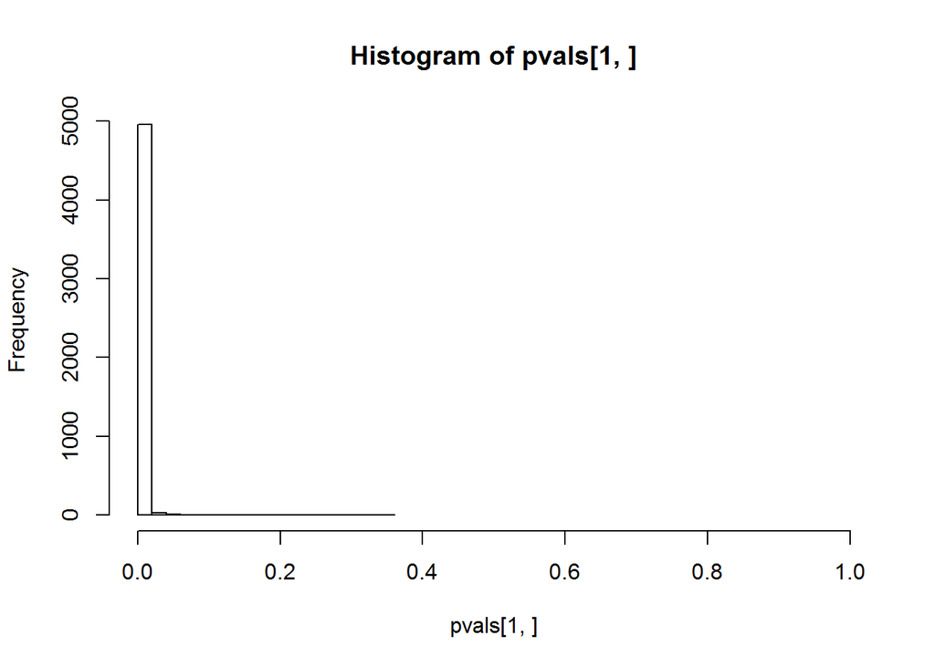

```r
hist(pvals[1,], xlim = c(0,1))
```

```r
sum(pvals[1,] < 0.05) / N
```

```
## [1] 0.9968
```

2. probablity of rejecting H0: the means in groups designated by the division of the variable levels2 are equal

As this null hypothesis is true, we are expecting to get value close to 0.

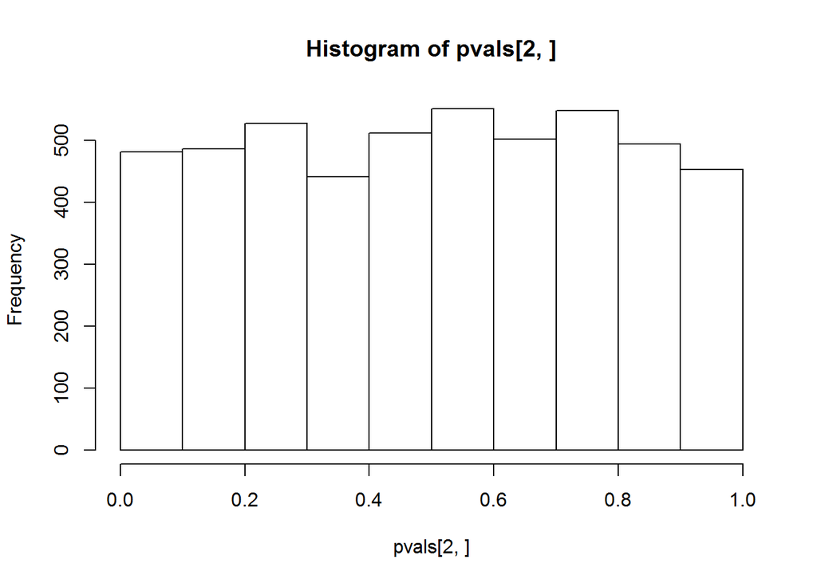

```r
hist(pvals[2,], xlim = c(0,1))
```

```r
sum(pvals[2,] < 0.05) / N
```

```
## [1] 0.0484
```

3. probability of rejecting H0: there are no interaction effects in the model

As this null hypothesis is true, we are expecting to get value close to 0.

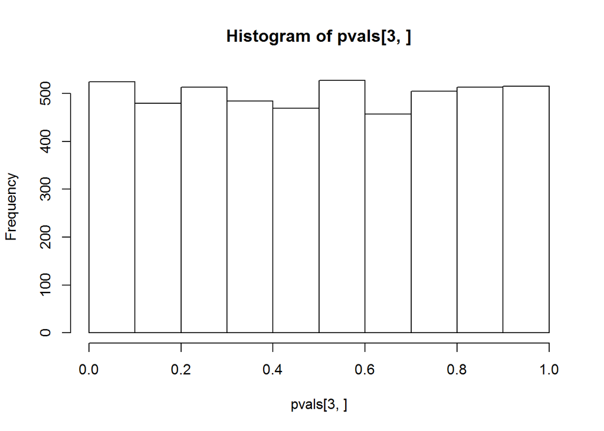

```r
hist(pvals[3,], xlim = c(0,1))
```

```r
sum(pvals[3,] < 0.05, na.rm = TRUE) / N
```

```
## [1] 0.0562
```

# Part II - adding interactions effects

In this scenario there are two groupping variables `levels1` and `levels2`. If an observation takes value 1 in both variables `levels1` and `levels2` we add 0.7 to this observation. Therefore, we are expecting strong interaction effects.

## Simulation

```r
N <- 5000
M <- 500
pvals <- replicate(N, {
      epsilon <- rnorm(M)
      levels1 <- sample(c(rep(0, 0.9 * M), rep(1, 0.1 * M)))
      levels2 <- sample(c(rep(0, 0.9 * M), rep(1, 0.1 * M)))
      y <- levels1 * levels2 * 0.7 + epsilon

      anova(lm(y~levels1 * levels2))[[5]][c(1,2,3)]

})
```

## Calculating probabilities

Probabilities of rejecting given null hypothesis are presented below:

1. probablity of rejecting H0: the means in groups designated by the division of the variable levels1 are equal

As this null hypothesis is true, we are expecting to get the value close to 0.

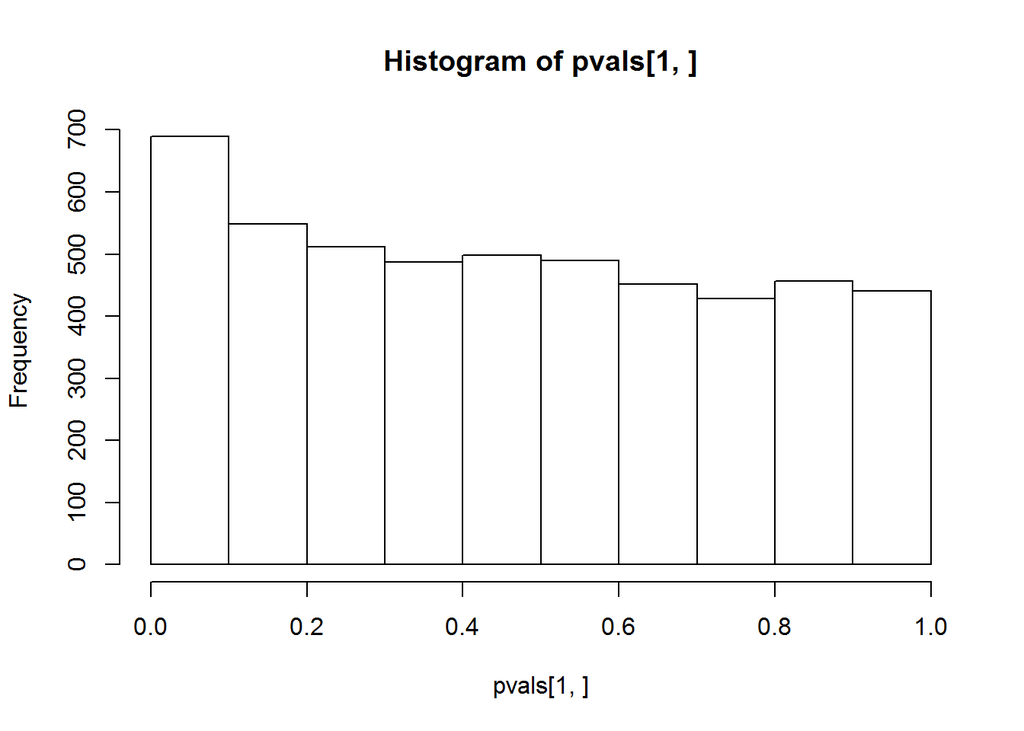

```r
hist(pvals[1,], xlim = c(0,1))
```

```r
sum(pvals[1,] < 0.05) / N
```

```
## [1] 0.0754
```

2. probablity of rejecting H0: the means in groups designated by the division of the variable levels2 are equal

As this null hypothesis is true, we are expecting to get value close to 0.

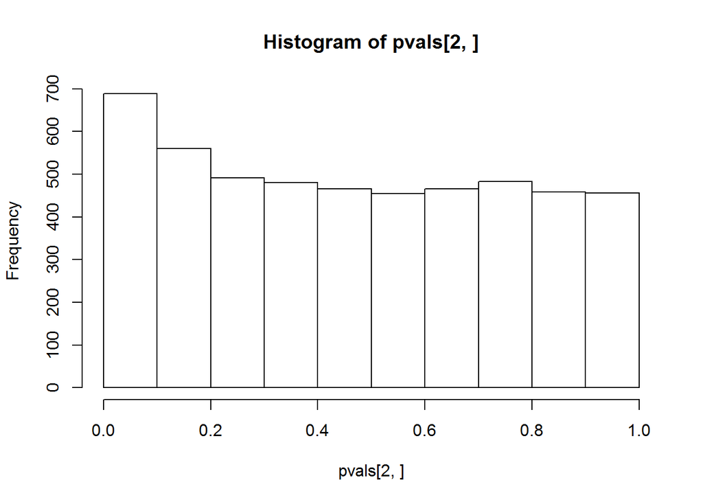

```r
hist(pvals[2,], xlim = c(0,1))
```

```r
sum(pvals[2,] < 0.05) / N
```

```
## [1] 0.074
```

3. probability of rejecting H0: there are no interaction effects in the model (power of the test for interaction effects)

As this null hypothesis not is true, we are expecting to get value close to 1.

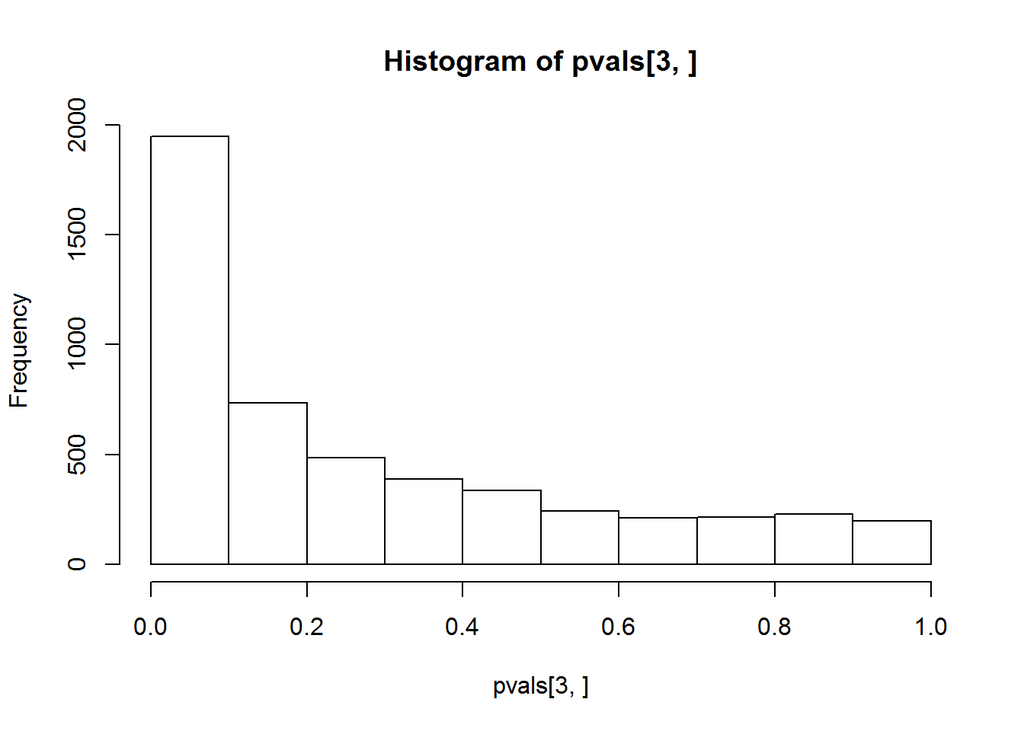

```r
hist(pvals[3,], xlim = c(0,1))
```

```r
sum(pvals[3,] < 0.05, na.rm = TRUE) / N
```

```
## [1] 0.278
```

# Part III

In this scenario there are, as above, two groupping variables `levels1` and `levels2`. If an observation takes value 1 in the variable `levels1` we add 0.7 to this observation. If the same observations takes value 1 in the variable `levels2` we add another 0.7 to it. Thus, we should notice main effect of the variable `levels1` and interaction effects.

## Simulation

```r
N <- 5000
M <- 500
pvals <- replicate(N, {
      epsilon <- rnorm(M)
      levels1 <- sample(c(rep(0, 0.9 * M), rep(1, 0.1 * M)))
      levels2 <- sample(c(rep(0, 0.9 * M), rep(1, 0.1 * M)))
      y <- levels1 * 0.7 + levels1 * levels2 * 0.7 + epsilon

      anova(lm(y~levels1 * levels2))[[5]][c(1,2,3)]

})
```

## Calculating probabilities

Probabilities of rejecting given null hypothesis are presented below:

1. probablity of rejecting H0: the means in groups designated by the division of the variable levels1 are equal (power of the test for main effect)

As this null hypothesis is not true, we are expecting to get the value close to 1.

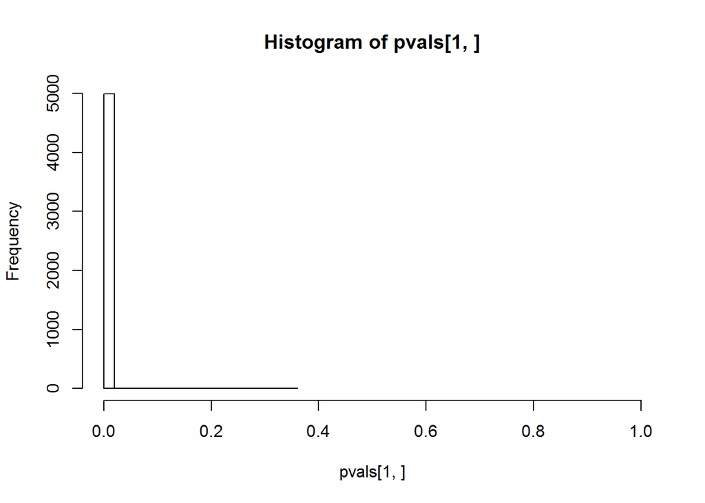

```r
hist(pvals[1,], xlim = c(0,1))
```

```r
sum(pvals[1,] < 0.05) / N
```

```
## [1] 0.999
```

2. probablity of rejecting H0: the means in groups designated by the division of the variable levels2 are equal

As this null hypothesis is true, we are expecting to get value close to 0.

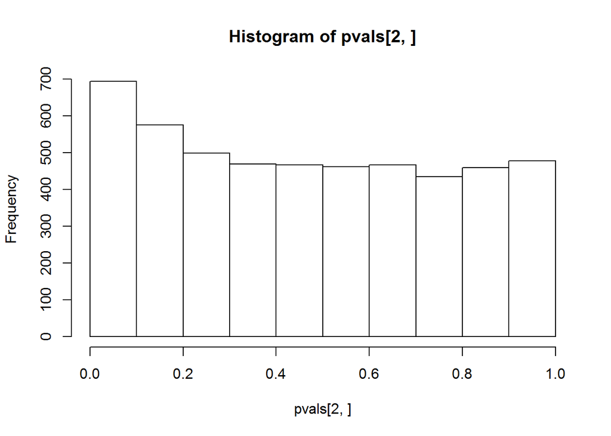

```r
hist(pvals[2,], xlim = c(0,1))
```

```r
sum(pvals[2,] < 0.05) / N
```

```
## [1] 0.0788
```

3. probability of rejecting H0: there are no interaction effects in the model (power of the test for interaction effects)

As this null hypothesis not is true, we are expecting to get value close to 1.

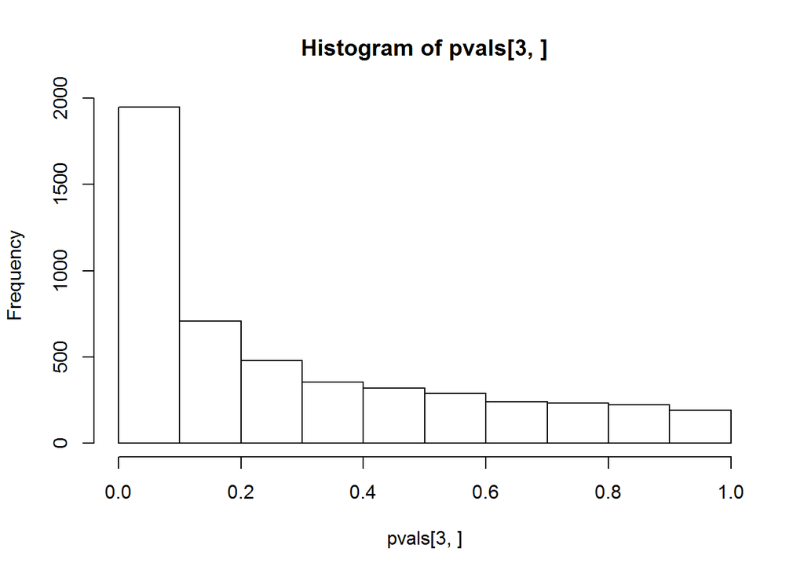

```r
hist(pvals[3,], xlim = c(0,1))
```

```r
sum(pvals[3,] < 0.05, na.rm = TRUE) / N
```

```
## [1] 0.276
```